### Based on Geodesic Polar Coordinate Algorithm

Published on https://onlinelibrary.wiley.com/doi/epdf/10.1111/j.1467-8659.2012.03187.x

# Implementation of Geodesic Polar Coordinates for Triangular Meshes

### Libraries

The libraries used are

- numpy for array math and linear algebra
- heapq for using a heap during the geodesics algorithm
- matplotlib and various sub libraries for plotting and visualization
- math for trig functions

```python
import numpy as np
import heapq as hq
import matplotlib.pyplot as plt
from mpl_toolkits.mplot3d import Axes3D
from mpl_toolkits.mplot3d.art3d import Poly3DCollection
import math
from random import randint
from scipy.spatial.transform import Rotation as R
import time
```

# Program Use

The only two neccesary things to adjust to get a base run of this program is adding a name to "filename" and changing the value "Umax"

The filename will be the name of the desired obj file without the file extension ".obj" typed at the end

for example if using "bunny.obj", filename will just be the word "bunny"

Umax is located in the cell under the markdown cell titled "Algorithm Values"

Umax will need to be adjusted per mesh as there is no standard size for obj inputs

Umax will want to be chosen so that a decently small size of the mesh is calculated for parameterization, otherwise the parameterization might create incorrect values.

```python
#enter file name without ".obj" at the end
filename = "cube"
#samples to make at each scale
numsamps = 150
```

## Loading OBJ Files

This section loads a given obj file into a series of triangles

Obj files in this program must be made up of triangles or quads and contain all vertices and vertex normals

```python
fo = open(filename + ".obj", "r")

#array of vertices, stored linearly in groups of 3
v = []
#temporary array of vertex normals
vntemp = []
#final array of vertex normals
vn = np.array([])
#index array of triangles stored linearly in groups of 3
f = []
str = fo.readline()
while str != "":
    temp = str.rstrip().split()
    #check if empty line
    if(len(temp) > 0):
        #if it is a face
        if (temp[0] == "f"):
            #if vn is empty, copy vertex array to place all vertex normals
            if(vn.size == 0):
                vn = np.copy(v)

            tempdat = []
            #if line has 5 elements / is a quad
            if (len(temp) == 5):
                for i in range(1,5):
                    tempsplit = temp[i].split("/")
                    #vertex index value
                    newn = int(tempsplit[0])-1
                    #normal index value
                    initn = int(tempsplit[2]) -1
                    #place normal in vertex normal array corresponding to the vertex in v
                    vn[newn*3:newn*3+3] = vntemp[initn*3:initn*3 + 3]
                    tempdat.append(newn)
                #break quad into 2 triangles and place them in the index array
                f += [tempdat[0],tempdat[1],tempdat[2],tempdat[0],tempdat[2],tempdat[3]]
            else:
                #assumes line has 4 elements and is a triangle
                for i in range(1,4):
                    tempsplit = temp[i].split("/")
                    #vertex index value
                    newn = int(tempsplit[0])-1
                    #normal index value
                    initn = int(tempsplit[2]) -1
                    #place normal in vertex normal array corresponding to the vertex in v
                    vn[newn*3:newn*3+3] = vntemp[initn*3:initn*3 + 3]
                    tempdat.append(newn)
                #place triangle indices in vertex
                f += tempdat
        #add vertex to vertex array
        if (temp[0] == "v"):
            v += [float(temp[1]),float(temp[2]),float(temp[3])]

        #add vertex normal to temporary array
        if (temp[0] == "vn"):
            vntemp += [float(temp[1]),float(temp[2]),float(temp[3])]

    str = fo.readline()
fo.close()
print("# of vertices ",len(v)/3)
print("# of triangles ",len(f)/3)
```

```
# of vertices  2648.0
# of triangles  5292.0
```

```python
#turn index and vertex array into numpy arrays
f = np.array(f)
v = np.array(v)
```

```python
def getArr(arr,i):
    #function gets 3 element array at given index i in an array arr
    return np.array([arr[i*3],arr[i*3+1],arr[i*3+2]])
def getInd(i):
    #get index given a position in an array divided into 3s
    return i // 3
```

```python
#triangles adjacent per vertex
triangleList = []
#adjacent vertices
vertexList = []

#get min and max values for display
maxx,maxy,maxz = -100000,-100000,-100000
minx,miny,minz = 100000,100000,100000

for i in range(0,v.size,3):
    triangleList.append([])
    vertexList.append([])
    if maxx < v[i]:
        maxx = v[i]
    elif minx > v[i]:
        minx = v[i]
    if maxy < v[i+1]:
        maxy = v[i+1]
    elif miny > v[i+1]:
        miny = v[i+1]
    if maxz < v[i+2]:
        maxz = v[i+2]
    elif minz > v[i+2]:
        minz = v[i+2]


for i in range(0,f.size,3):
    #add adjacent triangles and adjacent vertices to array
    triangleList[f[i]].append(getInd(i))
    vertexList[f[i]] += [f[i+1],f[i+2]]

    triangleList[f[i+1]].append(getInd(i))
    vertexList[f[i+1]] += [f[i],f[i+2]]

    triangleList[f[i+2]].append(getInd(i))
    vertexList[f[i+2]] += [f[i],f[i+1]]

for i in range(0,len(vertexList)):
    #turn arrays to sets to make sure theyre unique
    vertexList[i] = set(vertexList[i])
    triangleList[i] = set(triangleList[i])

print(maxx - minx)
print(maxy - miny)
print(maxz - minz)
print(((maxx - minx) * (maxy - miny) * (maxz - minz))/len(v)/3)
```

```
1.412004
1.412004
1.412004
0.00011812648762150791
```

## Plotting

The following cells plot various vertices of the obj file as well as the full obj model from 2 different angles

```python
# #display range of vertices
# fig = plt.figure()
# ax = fig.add_subplot(111, projection='3d')
# starty = 0
# endy = 70
# plt.title("Range of Vertices Plotted")
# ax.scatter(v[starty*3:endy*3:3],v[starty*3+1:endy*3+1:3],v[starty*3+2:endy*3+2:3])
# plt.show()
```

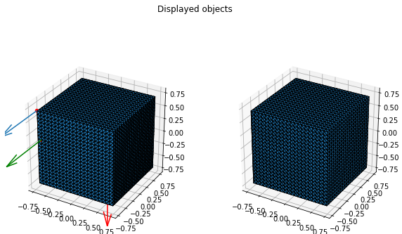

```python
#set up plots
fig = plt.figure(figsize=(10,10))
ax = fig.add_subplot(221, projection='3d')
ax2 = fig.add_subplot(222, projection='3d')
scale = 1.5
ax.set_xlim(minx-0.1, maxx+0.1)
ax.set_ylim(miny-0.1, maxy+0.1)
ax.set_zlim(minz-0.1, maxz+0.1)
ax2.set_xlim(minx-0.1, maxx+0.1)
ax2.set_ylim(miny-0.1, maxy+0.1)
ax2.set_zlim(minz-0.1, maxz+0.1)

tvx = []
tvy = []
tvz = []


for i in range(0,f.size,3):
    #vertices per triangle are placed in numpy array for display
    vtx = np.array([getArr(v,f[i]),getArr(v,f[i+1]),getArr(v,f[i+2])])
    vtx2 = np.array([getArr(v,f[i]),getArr(v,f[i+1]),getArr(v,f[i+2])])
    #flip coords for second display
    temp = np.copy(vtx2[:,0])
    vtx2[:,0] = vtx2[:,1]
    vtx2[:,1] = temp
    #add triangles to display collections
    tri = Poly3DCollection([vtx])
    tri.set_edgecolor('k')
    tri2 = Poly3DCollection([vtx2])
    tri2.set_edgecolor('k')
    ax.add_collection3d(tri)
    ax2.add_collection3d(tri2)
#display given points with normal arrows
vertS = randint(0,len(v)/3 - 1) * 3
ax.scatter(v[vertS],v[vertS+1],v[vertS+2], c="r")
ax.quiver(v[vertS],v[vertS+1],v[vertS+2],vn[vertS],vn[vertS+1],vn[vertS+2],colors="Green",normalize=True)
vertS = randint(0,len(v)/3 - 1) * 3
vertS = 0 * 3
ax.scatter(v[vertS],v[vertS+1],v[vertS+2], c="r")
ax.quiver(v[vertS],v[vertS+1],v[vertS+2],vn[vertS],vn[vertS+1],vn[vertS+2],normalize=True)
vertS = randint(0,len(v)/3 - 1) * 3
ax.scatter(v[vertS],v[vertS+1],v[vertS+2], c="r")
ax.quiver(v[vertS],v[vertS+1],v[vertS+2],vn[vertS],vn[vertS+1],vn[vertS+2],colors="Red",normalize=True)
fig.suptitle("Displayed objects")
plt.show()
```

## Geodesic Polar Coordinate Algorithm

The following functions apply the geodesic polar coordinate algorithm on a triangular mesh based on a specific starting point on the mesh

```python
#compute distance
def computeDistance(vi,vj,vk,Uj,Uk,s,j,k):
    #uijkloc is 0 if xj and xk > 0, 1 if updated from j, 2 if updated from k
    uijkloc = 0

    ej = vj - vi
    ek = vk - vi
    ekj = vk - vj
    ekj2 = np.dot(ekj,ekj)

    A = np.linalg.norm(np.cross(ej,ek))
    #H = np.sqrt((ekj2 - pow(Uj - Uk,2) )* (pow(Uj + Uk,2) - ekj2))



    #more stable version of heron's formula
    hset = [Uk,Uj,np.linalg.norm(ekj)]
    hset.sort(reverse=True)
    hinner = (hset[0] + (hset[1] + hset[2]))*(hset[2]- (hset[0] -hset[1]))*(hset[2]+ (hset[0] -hset[1]))*(hset[0] + (hset[1] -hset[2]))

    #this check is for if any pair of Uj, Uk or ejk add up to the third entry, in which case it will be a degenerate triangle
    if hinner <= 0:
        return float("inf"), 0, np.array([0,0,0])
        #hinner = 0

    H= np.sqrt(hinner)

    #calculate xj and xk, values for s point projection
    xj = (A * (ekj2 + pow(Uk,2) - pow(Uj,2)) + np.dot(ek, ekj) * H)/(2 * A * ekj2)
    xk = (A * (ekj2 + pow(Uj,2) - pow(Uk,2)) - np.dot(ej, ekj) * H)/(2 * A * ekj2)

    Uijk = 0
    #step to find min value of Uijk
    if (xj > 0 and xk > 0):
        Uijk = np.linalg.norm(xj * ej + xk * ek)
    else:
        tempuk = Uk + np.linalg.norm(ek)
        tempuj = Uj + np.linalg.norm(ej)
        if tempuj < tempuk:
            uijkloc = 1
            Uijk = tempuj
        else:
            uijkloc = 2
            Uijk = tempuk
    #calculate s projection point
    sp = vi + xj * ej + xk * ek
    return Uijk, uijkloc, sp
```

```python
def computeAngle(vi,vj,vk,sp, thetaj, thetak, uijkloc, i):
    #comput angle for new polar co-ordinate


    #return if calculated from previously calculated coordinate
    if uijkloc == 1:
        return thetaj% (2*math.pi)
    elif uijkloc == 2:
        return thetak% (2*math.pi)


    #prevent 360 degree comparisons
    thetaj2 = thetaj
    thetak2 = thetak
    if (thetaj > thetak):
        diffang = thetaj - thetak
        if (diffang >= math.pi):
            thetaj2 -= 2*math.pi
    if (thetaj < thetak):
        diffang = thetak - thetaj
        if (diffang >= math.pi):
            thetak2 -= 2*math.pi


    #get angles between Uj and Uijk, and Uj and Uk from the projection point sp
    vks = vk- sp
    vjs = vj - sp
    vis = vi - sp
    vks = vks / np.linalg.norm(vks)
    vjs = vjs / np.linalg.norm(vjs)
    vis = vis / np.linalg.norm(vis)
    pkjin = np.dot(vks,vjs)/np.linalg.norm(vks) * np.linalg.norm(vjs)
    pijin = np.dot(vis,vjs)/np.linalg.norm(vis) * np.linalg.norm(vjs)


    if (pkjin < -1):
        pkjin = -1
    elif(pkjin > 1):
        pkjin = 1
    if (pijin < -1):
        pijin = -1
    elif(pijin > 1):
        pijin = 1
    #get angle percentage alpha that phi ij is of phi kj
    phikj = math.acos(pkjin)
    phiij = math.acos(pijin)
    alpha = phiij / phikj
    #get final angle
    finang = ((1 - alpha)*thetaj2 + alpha * thetak2) % (2*math.pi)
    return finang
```

```python
def projectVec(normal, vec):
    #project a vector onto a plane given the plane's normal
    projection = vec - (np.dot(vec,normal) / pow(np.linalg.norm(normal),2))*normal
    return projection
def getAngle(normal, x, vec):
    #get angle between to vectors with respect to a plane given the planes normal
    #x is the reference vector
    angle = math.atan2((np.dot(normal, np.cross(x,vec))),np.dot(x,vec))
    angle = (angle + 2*math.pi) % (2*math.pi)
    return angle
```

```python
def initializeNeighbourhood(s):
    #U is the distance of the vertex
    U = []
    #theta is the angle of the vertex from the reference vector
    theta = []
    #checked is an array of which vertices have been checked in the algorithm
    checked = []
    #candidates is a heap that stores the closest distance vertex and the reference vertex
    candidates = []
    #intialize arrays
    for i in range(0,v.size,3):
        U.append(1000000)
        theta.append(0)
        checked.append(False)

    #x is the angle reference vector, s is the index of main vertex
    x = np.array([])
    xind = 0
    #initial point angle and distance will be 0
    U[s] = 0
    theta[s] = 0
    checked[s]= True
    #initialize all adjacent vertices to initial point
    for i in vertexList[s]:
        temp = getArr(v,i) - getArr(v,s)
        #intialize first checked vertex as reference angle
        if x.size == 0:
            xind = i
            x = projectVec(getArr(vn,s), temp)
        #get distance for neighbouring vertex
        U[i] = np.linalg.norm(temp)
        #push distance to vertex as well as vertex number
        hq.heappush(candidates,(U[i],i))
        #get angle projected onto plane from main vertex's normal
        theta[i] = getAngle(getArr(vn,s), x, temp)
        checked[i] = True
    return x, U, theta, checked, candidates, xind
```

## Algorithm Values

Umax is the maximum radius that the algorithm will update vertex distances, this value most likely needs to be experimented with to get desireable results

```python
#x is main rotation axis of polar map

#random starting vertex
s = randint(0,len(v)/3 - 1)
eps = 0.0000001
#Umax = 0.1 #recommended for bunny
Umax = 1.75 #recommended for sphere

def geodesicAlgo(s,Umax,eps):
    x, U, theta, checked, candidates, xind = initializeNeighbourhood(s)
    #keep going while candidates list is not empty
    while len(candidates) >0:
        #pull closest candidate's distance and index
        newpop = hq.heappop(candidates)
        Uj = newpop[0]
        j = newpop[1]
        #for all vertices adjacent to j
        for i in vertexList[j]:
            #intersection of triangles containing i and j
            sameTriangles = triangleList[j] & triangleList[i]
            #pull triangles from set
            while len(sameTriangles) > 0:
                triArr = np.copy(getArr(f,sameTriangles.pop()))
                k = np.delete(triArr,np.where(triArr==i))
                #get third vertex and determine if a value for it has been calculated for it yet
                k = np.delete(k,np.where(k==j))[0]
                if checked[k] == True:
                    #run compute distance
                    newUi, uijkloc, sp = computeDistance(getArr(v,i),getArr(v,j),getArr(v,k),U[j],U[k],getArr(v,s),j,k)
                    #if new distance is smaller than calculated distance given some threshold
                    if (U[i] / newUi) > (1 + eps):
                        #set new closer distance and get angle
                        U[i] = newUi
                        checked[i] = True
                        theta[i] = computeAngle(getArr(v,i),getArr(v,j),getArr(v,k),sp,theta[j],theta[k],uijkloc,i)
                        #theta[i] = computeAngle(getArr(v,i),getArr(v,j),getArr(v,k),getArr(v,s),theta[j],theta[k],uijkloc,i)
                        #if distance is inside range, push to candidates
                        if newUi < Umax:
                            hq.heappush(candidates, (U[i],i))
    return U, theta, checked, xind
U, theta, checked, xind = geodesicAlgo(s,Umax,eps)
print(Umax)
```

```
1.75
```

## Various Plots of the Polar Coordinates

[figure not shown]

```python
#create arrays for displaying polar coordinates
Ua = []
Ta = []
#populate arrays with all coordinates with a distance less than 1000
for i in range(0,len(U)):
    if (U[i] < 1000):
        Ua.append([U[i], i])
        Ta.append([theta[i], i])
Ua = np.array(Ua)
Ta = np.array(Ta)
plt.figure(figsize=(7,7))
plt.polar(Ta[:,0:1],Ua[:,0:1],'ro')
plt.title("Polar Coordinates Plotted")
plt.show()
```

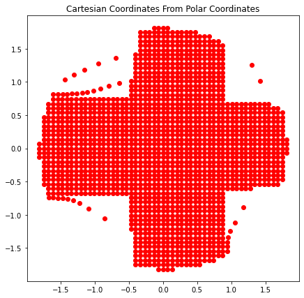

```
1640
```

```python
Xa = np.copy(Ua)
Ya = np.copy(Ua)
#convert polar coordinated to cartesian coordinates
Xa[:,0:1] = Ua[:,0:1] * np.cos(Ta[:,0:1])
Ya[:,0:1] = Ua[:,0:1] * np.sin(Ta[:,0:1])
plt.figure(figsize=(7,7))
plt.plot(Xa[:,0:1],Ya[:,0:1],'ro')
plt.title("Cartesian Coordinates From Polar Coordinates")
plt.show()
print(s)
```

```python
#convert all points to cartesian with original indexes
xcart = U * np.cos(theta)
ycart = U * np.sin(theta)
```

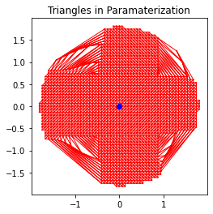

```python
#array of triangles with all checked vertices
fchecked = np.array([])
for i in range(0,f.size,3):
    if (checked[f[i]] == True and checked[f[i+1]] == True and checked[f[i+2]] == True ):
        fchecked = np.append(fchecked,f[i:i+3])


#plot all checked triangles

fig2, ax2 = plt.subplots()
ax2.set_aspect('equal')
fchecked = np.reshape(fchecked, (fchecked.size//3, 3))
ax2.plot(0, 0, 'bo', lw=1.0)
ax2.triplot(xcart, ycart, fchecked, 'r-', lw=1.0)
plt.title("Triangles in Paramaterization")

plt.show()
fig2.savefig("./paper/sphereparam.pdf", bbox_inches='tight')
```

## Laplacian on Paramaterization

The following cells apply a laplacian to the geodesic paramaterization and move the object vertices based on an inverse vertex function utilizing barycentric coordinates

```python
#checks if all vertices in list l have been checked
def listChecked(l):
    for i in l:
        if checked[i] == False:
            return False
    return True
```

```python
#cartesian coordinates to barycentric coordinates, given 3 vertices and point p
def cartToBary(vi,vj,vk,p):
    area = np.linalg.norm(np.cross(vj-vi, vk-vi)) * 0.5
    b = (np.linalg.norm(np.cross(p - vi, vk- vi)) *0.5) / area
    a = (np.linalg.norm(np.cross(p - vk, vj- vk)) *0.5) / area
    #c = (np.linalg.norm(np.cross(p - vj, vi- vj)) *0.5) / area
    c = 1.0 - (a + b)
    return np.array([a,b,c])
#barycentric coordinates to cartesian coordinates, given 3 vertices and barycentric coordinates in an array abc
def baryToCart(abc,vi,vj,vk):
    return abc[0] * vi + abc[1] * vj + abc[2] * vk
```

```python
#checks if point p is contained in triangle [vi,vj,vk]
def pointContained(vi,vj,vk,p):
    uj = vj - vi
    uk = vk - vi
    #print(np.linalg.det(np.vstack((uj,uk)).T))
    if (np.linalg.det(np.vstack((uj,uk)).T) == 0):
#         print("vi ", vi, " vj ", vj, " vk ", vk, " p ", p)
#         print(np.vstack((uj,uk)).T)
        return False
    a = np.linalg.inv(np.vstack((uj,uk)).T)
    xu = np.dot(a, (p - vi))
    if (xu[0] < 0 or xu[1] < 0):
        return False
    if (np.sum(xu) > 1):
        return False
    return True
```

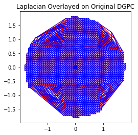

```python
#beta between 0 and 1
beta = 0.9
def laplacian(beta):
    #object vertices to store laplacian version of vertices
    v2 = np.copy(v)
    #cartesian coordinates to store the laplacian version of coordinates
    xcart2 = np.copy(xcart)
    ycart2 = np.copy(ycart)
    for i in range (0, len(checked)):
        #check if vertex has been claculated
        if checked[i]:
            adj = list(vertexList[i])
            #check if all adjacent vertices have been checked as well
            if (listChecked(adj) == True):
                #average surrounding vertices
                ipoint = np.array([xcart[i],ycart[i]])
                totx = 0
                toty = 0
                for vert in adj:
                    totx += xcart[vert] - ipoint[0]
                    toty += ycart[vert] - ipoint[1]
                totx = totx / len(adj) * beta
                toty = toty / len(adj) * beta
                newP = np.array([xcart[i] + totx, ycart[i] + toty])
                #get laplacian version of coordinate
                xcart2[i] = newP[0]
                ycart2[i] = newP[1]
                #find which triangle new point lies in
                for tris in list(triangleList[i]):
                    triInds = getArr(f,tris)
                    vi2= np.array([xcart[triInds[0]],ycart[triInds[0]]])
                    vj2 =np.array([xcart[triInds[1]],ycart[triInds[1]]])
                    vk2 =np.array([xcart[triInds[2]],ycart[triInds[2]]])
                    if pointContained(vi2,vj2,vk2,newP):
                        #if point is in current triangle, get barycentric coordinate in parameter mesh and displace object
                        #to that point
                        baryCoord = cartToBary(vi2,vj2,vk2,newP)
                        vi3 = getArr(v,triInds[0])
                        vj3 = getArr(v, triInds[1])
                        vk3 = getArr(v, triInds[2])
                        vpnew3 = baryToCart(baryCoord, vi3,vj3,vk3)
                        v2[i*3:i*3 + 3] = vpnew3
    return v2, xcart2, ycart2
v2, xcart2, ycart2 = laplacian(beta)

#plot paramaterization and laplacian paramterization over each other
fig2, ax2 = plt.subplots()
ax2.set_aspect('equal')
fchecked = np.reshape(fchecked, (fchecked.size//3, 3))
ax2.plot(0, 0, 'bo', lw=1.0)
ax2.triplot(xcart, ycart, fchecked, 'r-', lw=1.0)
ax2.triplot(xcart2, ycart2, fchecked, 'b-', lw=1.0)
plt.title("Laplacian Overlayed on Original DGPC")
plt.show()
#plt.savefig("plot.pdf")
```

## Mesh Grid Resampling on the Parameterization

The following cell resamples the parameterization on a uniform grid

```python
def BoundBox(vi, vj, vk):
    maxx = max(vi[0], vj[0], vk[0])
    maxy = max(vi[1], vj[1], vk[1])
    minx = min(vi[0], vj[0], vk[0])
    miny= min(vi[1], vj[1], vk[1])
    return [minx, miny, maxx-minx, maxy- miny]
```

```python
def Collision(bbSq, bbTri):
    if (bbSq[0] < bbTri[0] + bbTri[2] and bbSq[0] + bbSq[2] > bbTri[0] and bbSq[1] < bbTri[1] + bbTri[3] and bbSq[1] + bbSq[3] > bbTri[1]):
        return True
    return False
```

```python
#dimension of sampling mesh grid
pointdimension = 31
start = time.perf_counter()
def resample(pointdimension):
    #space sampled over is a square that is half the size of Umax
    xdim = np.linspace(-1 * (Umax / 2), Umax / 2, pointdimension)
    ydim = np.linspace(-1 * (Umax / 2), Umax / 2, pointdimension)
    xsamp, ysamp = np.meshgrid(xdim, ydim)
    #change coordinates into 1 dimensional arrays
    xsamp = np.reshape(xsamp, xsamp.size)
    ysamp = np.reshape(ysamp, ysamp.size)
    vRes = np.zeros(pointdimension * pointdimension * 3)
    fRes = []
    #setup face values for vertices
    for i in range(0,pointdimension-1):
        for j in range(0,pointdimension-1):
            fRes += [i*pointdimension+1+j,pointdimension*i + 2+j, pointdimension * i + pointdimension + 1+j]
            fRes += [i*pointdimension + 2+j, pointdimension * i + 2 + pointdimension+j, pointdimension * i + 1 + pointdimension+j]

    #########################################################################
    #Bounding box setup
    fchkBB = []
    for i in range(fchecked.shape[0]):
        triInds = fchecked[i]
        vi2= np.array([xcart2[int(triInds[0])],ycart2[int(triInds[0])]])
        vj2 =np.array([xcart2[int(triInds[1])],ycart2[int(triInds[1])]])
        vk2 =np.array([xcart2[int(triInds[2])],ycart2[int(triInds[2])]])
        fchkBB.append(BoundBox(vi2,vj2,vk2))

    partDimP = pointdimension//2
    xpartdim = np.linspace(-1 * (Umax / 1.5), Umax / 1.5, partDimP)
    ypartdim = np.linspace(-1 * (Umax / 1.5), Umax / 1.5, partDimP)
    xparts, yparts = np.meshgrid(xpartdim, ypartdim)
    triParts=[]
    for i in range(0,partDimP-1):
        triParts.append([])
        for j in range(0,partDimP-1):
            triParts[i].append([])
    boxWidth = ((Umax/1.5) * 2) / (partDimP-1)


    for i in range(len(fchkBB)):
        for j in range(0,partDimP-1):
            for k in range(0,partDimP-1):
                bbSq = [xparts[j][k], yparts[j][k], boxWidth, boxWidth]
                if Collision(bbSq, fchkBB[i]):
                    triParts[j][k] += [i]

    for i in range(0,partDimP-1):
        for j in range(0,partDimP-1):
            triParts[i][j] = list(set(triParts[i][j]))

    #Draw stuff
    #############################################################################
#     fDraw= []
#     for i in triParts[1][2]:
#         fDraw.append(fchecked[i])
#     testBB = fchkBB[0]
#     print(testBB)
#     #plt.plot([testBB[0], testBB[0] + ])
#     f = plt.figure()
#     f = plt.figure(figsize=(8,8))
#     plt.plot(xparts,yparts,'ro')
#     plt.triplot(xcart2, ycart2, fchecked, 'b-', lw=1.0)
#     plt.triplot(xcart2, ycart2, fDraw, 'g-', lw=2.0)
#     plt.title("Grid Partitioning For Triangles")
#     plt.show()
#     f.savefig("./paper/tripartition.pdf", bbox_inches='tight')
    ###############################################################################

    failed = False
    for i in range(xsamp.size):
        contained = False
        alone = True
        curp = np.array([xsamp[i], ysamp[i]])
        px = int((curp[0]+ Umax/1.5) // (((Umax/1.5)*2) / (partDimP - 1)))
        py = int((curp[1]+ Umax/1.5) // (((Umax/1.5)*2) / (partDimP - 1)))
        #find which triangle sampling point is contained in
        for triF in triParts[py][px]:
            triInds = fchecked[triF]
            vi2= np.array([xcart2[int(triInds[0])],ycart2[int(triInds[0])]])
            vj2 =np.array([xcart2[int(triInds[1])],ycart2[int(triInds[1])]])
            vk2 =np.array([xcart2[int(triInds[2])],ycart2[int(triInds[2])]])
            if pointContained(vi2,vj2,vk2,curp):

                if contained == True:
                    failed = True
                else:
                    contained = True
                    alone = False
                #when found resample using barycentric coordinates
                baryCoord = cartToBary(vi2,vj2,vk2,curp)
                vi3 = getArr(v2,int(triInds[0]))
                vj3 = getArr(v2, int(triInds[1]))
                vk3 = getArr(v2, int(triInds[2]))
                vpnew3 = baryToCart(baryCoord, vi3,vj3,vk3)
                vRes[i*3:i*3 + 3] = vpnew3
        if alone == True:
            failed = True
            #print("in no triangles")

    #########################################################################

    #go through cordinates of sampling over parameterization

#     for i in range(xsamp.size):
#         curp = np.array([xsamp[i], ysamp[i]])
#         #find which triangle sampling point is contained in
#         for triInds in fchecked:
#             vi2= np.array([xcart2[int(triInds[0])],ycart2[int(triInds[0])]])
#             vj2 =np.array([xcart2[int(triInds[1])],ycart2[int(triInds[1])]])
#             vk2 =np.array([xcart2[int(triInds[2])],ycart2[int(triInds[2])]])
#             if pointContained(vi2,vj2,vk2,curp):
#                 #when found resample using barycentric coordinates
#                 baryCoord = cartToBary(vi2,vj2,vk2,curp)
#                 vi3 = getArr(v2,int(triInds[0]))
#                 vj3 = getArr(v2, int(triInds[1]))
#                 vk3 = getArr(v2, int(triInds[2]))
#                 vpnew3 = baryToCart(baryCoord, vi3,vj3,vk3)
#                 vRes[i*3:i*3 + 3] = vpnew3

#     end = time.perf_counter() - start
#     print(f"time {end:0.4f}")

    return fRes, vRes, failed


fRes, vRes, failed = resample(pointdimension)
end = time.perf_counter() - start
print(f"time {end:0.4f}")
```

```
time 1.9800
```

## Object Outputs

The following cells save the uniform grid resampling as a mesh as well as the displaced laplacian object as a mesh

```python
#output mesh resample
fo2 = open(filename + "testsample.obj", "w")
for i in range(0,vRes.size,3):
    fo2.write("v %.6f %.6f %.6f\n"%(vRes[i],vRes[i+1],vRes[i+2]))
for i in range(0,len(fRes),3):
    fo2.write("f %d %d %d\n"%(fRes[i],fRes[i+1],fRes[i+2]))
fo2.close()
```

```python
#output object with laplacian resampling
fo2 = open(filename + "laplacian.obj", "w")
for i in range(0,v2.size,3):
    fo2.write("v %.6f %.6f %.6f\n"%(v2[i],v2[i+1],v2[i+2]))
for i in range(0,vn.size,3):
    fo2.write("vn %.6f %.6f %.6f\n"%(vn[i],vn[i+1],vn[i+2]))
fwr = np.copy(f)+1
for i in range(0,f.size,3):
    fo2.write("f %d//%d %d//%d %d//%d\n"%(fwr[i],fwr[i],fwr[i+1],fwr[i+1],fwr[i+2],fwr[i+2]))
fo2.close()
```

# Test Use

The following two cell is just to test the functions automatically

The cell will pick a few random points on the mesh and output some mesh resamples, to view their accuracy they can all be placed into mesh lab along with the original mesh, if the resampling worked it should appear to be similar in topology to a portion of the original mesh, with a slightly smoother surface.

```python
start = time.perf_counter()
for scale in range(0,3):
    scalemat = np.array([[scale * 0.5+ 1,0,0],[0,1 + scale* 0.5,0],[0,0,1 + scale* 0.5]])
    for i in range(v.size//3):
            v[i*3:i*3 +3] = np.dot(scalemat, v[i*3:i*3 +3])
    for j in range(0,150):
        failed = True
        while failed == True:
            s = randint(0,len(v)/3 - 1)
            U, theta, checked, xind = geodesicAlgo(s,Umax,eps)
            xcart = U * np.cos(theta)
            ycart = U * np.sin(theta)
            fchecked = np.array([])
            for i in range(0,f.size,3):
                if (checked[f[i]] == True and checked[f[i+1]] == True and checked[f[i+2]] == True ):
                    fchecked = np.append(fchecked,f[i:i+3])
            fchecked = np.reshape(fchecked, (fchecked.size//3, 3))
            v2, xcart2, ycart2 = laplacian(0.9)
            fRes, vRes, failed = resample(pointdimension)
        #fo2 = open("./"+filename+"/" + filename + "multisample%df%ds%d.obj"%(failed, scale, j), "w")
        fo2 = open("./"+filename+"/" + filename + "multisample%ds%d.obj"%(scale, j), "w")
        if (j % 100 == 0):
            print(filename + "multisample%ds%d.obj"%(scale,j))
        for i in range(0,vRes.size,3):
            fo2.write("v %.6f %.6f %.6f\n"%(vRes[i],vRes[i+1],vRes[i+2]))
        for i in range(0,len(fRes),3):
            fo2.write("f %d %d %d\n"%(fRes[i],fRes[i+1],fRes[i+2]))
        fo2.close()
        angoal = np.array([1,0,0])
        rotnormal1 = np.array([0,1,0])
        rotnormal2 = np.array([0,0,1])
        rotgoal1 = np.array([1,0,0])
        snorm = getArr(vn, s)
        ang1 = getAngle(rotnormal1, rotgoal1, snorm)
        r1 = R.from_euler('y', -1.0 * ang1, degrees=False)
        snorm2 = np.dot(r1.as_matrix(), snorm)
        ang2 = getAngle(rotnormal2, angoal, snorm2)
        r2 = R.from_euler('z', -1.0 * ang2, degrees=False)
        snorm2 = np.dot(r2.as_matrix(), snorm2)
        rf = np.dot(r2.as_matrix(),r1.as_matrix())
        vcanon = np.copy(vRes)
        spoint = getArr(v,s)
        vcanon[::3] -= spoint[0]
        vcanon[1::3] -= spoint[1]
        vcanon[2::3] -= spoint[2]
        xp = getArr(v,xind) - spoint
        for i in range(vcanon.size//3):
            vcanon[i*3:i*3 +3] = np.dot(rf, vcanon[i*3:i*3 +3])

        xp = np.dot(rf, xp)
        ang3 = getAngle(rotgoal1, np.array([0,0,-1]), xp)
        r3 = R.from_euler('x', -1.0 * ang3, degrees=False)
        for i in range(vcanon.size//3):
            vcanon[i*3:i*3 +3] = np.dot(r3.as_matrix(), vcanon[i*3:i*3 +3])


        #fo2 = open("./"+filename+"/" + filename + "multisamplecanonical%df%ds%d.obj"%(failed,scale,j), "w")
        fo2 = open("./"+filename+"/" + filename + "multisamplecanonical%ds%d.obj"%(scale,j), "w")
        if (j % 10 == 0):
            print(filename + "multisamplecanonical%ds%d.obj"%(scale, j))
            end = time.perf_counter() - start
            print(f"Total time {end:0.4f}")
        for i in range(0,vcanon.size,3):
            fo2.write("v %.6f %.6f %.6f\n"%(vcanon[i],vcanon[i+1],vcanon[i+2]))
        for i in range(0,len(fRes),3):
            fo2.write("f %d %d %d\n"%(fRes[i],fRes[i+1],fRes[i+2]))
        fo2.close()
end = time.perf_counter() - start
print(f"Total time {end:0.4f}")
```

[output not shown]

[output cut: 42 more lines]

[output not shown]